# Forecasting # of visitors from Hong Kong

### CMV

```r
source("source.R")
TS_SE1 <- read.csv("HK.csv")
Visitors <- TS_SE1$HK
Quarter <- TS_SE1$Month
Season <- max(Quarter)
Period <- TS_SE1$period
t  = Period -1
n <- length(Visitors)
CMV_SI <- Center_Moving_Average(Visitors, Quarter, Season)
cat("# # # # The Centered moving average seasonal index # # # ","\n")
```

```
# # # # The Centered moving average seasonal index # # #
```

```r
print(CMV_SI)
```

```
 [1] 0.7262341 0.8141025 1.0395370 1.1596047 0.9553204 1.1340336 1.1149222 1.2092273 0.8600243
[10] 0.8724872 0.9115172 1.2029895
```

```r
write.csv(CMV_SI,"../../temp.csv")
```

### Forecast by seasonal index

```
### Linear Model ###
Call:
lm(formula = Des_x ~ t)

Residuals:
   Min     1Q Median     3Q    Max
-35270  -6700    354   7274  33608

Coefficients:
            Estimate Std. Error t value Pr(>|t|)
(Intercept) 61801.34    2148.09   28.77   <2e-16 ***
t             753.55      34.69   21.72   <2e-16 ***
---
Signif. codes:  0 ‘***’ 0.001 ‘**’ 0.01 ‘*’ 0.05 ‘.’ 0.1 ‘ ’ 1

Residual standard error: 11240 on 106 degrees of freedom
Multiple R-squared:  0.8166,    Adjusted R-squared:  0.8148
F-statistic: 471.8 on 1 and 106 DF,  p-value: < 2.2e-16


    Shapiro-Wilk normality test

data:  Standard_E
W = 0.9862, p-value = 0.3321

run test:[1] 0.1219004
The Outliers[1]  71  72  84  96 107
influential observations:[1] "no influential observations"
mean_y: 102116.1



deseasonalized data:
  [1]  68602.12  64040.43  61916.43  61682.36  61561.05  65244.51  62059.17  64715.44  56835.66
 [10]  72736.54  53302.58  71595.09  54770.11  60067.00  62555.04  61106.79  58121.61  66553.41
 [19]  68085.38  75577.55  84056.91  62070.81  75411.46  90223.85  74138.48  87813.10  79489.85
 [28]  78405.44  83716.24  77839.54  77552.02  75324.01  74634.33  94351.76 103877.02  69307.24
 [37]  95921.75 101249.21  90796.47  91594.03  91055.57 100242.16  98884.58  92690.75  95896.07
 [46] 102200.89  89930.42 119322.56 115245.11 108494.14 110641.80 109491.41 113021.23 102086.32
 [55] 102922.90 101718.26  95857.51 107815.67 103274.82 117850.51 122445.83 113166.84 116526.52
 [64] 116824.19 124951.12 121094.05 121811.19 122595.42 120585.08 126404.24 148157.31  88541.38
 [73] 122099.35 115154.44 120722.33 118316.88 124908.10 134646.11 128873.04 133070.15 143331.18
 [82] 117492.58 111155.26 153372.96 125656.27 119204.58 125197.97 128931.09 126574.33 122423.58
 [91] 135583.83 131045.20 136148.93 119437.05 134124.14  98117.92 118936.01 118862.44 130793.88
[100] 139477.50 127060.36 127519.36 135851.52 124651.96 128315.37 130746.44 113074.38 147019.07
```

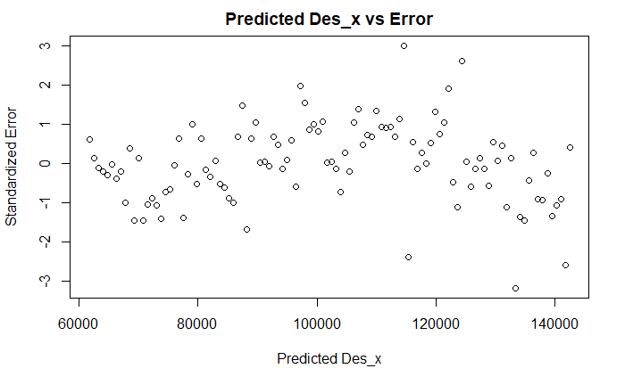

```r
Forecast_Visitors_CMV= Forecast_by_SI(Visitors, Quarter, Season, CMV_SI, t)
```

```r
cat("# # # # The Forecast_Visitors_y # # # ","\n")
```

```
# # # # The Forecast_Visitors_y # # #
```

```r
print(Forecast_Visitors_CMV)
```

```
  [1]  59040.08  70939.34  70583.98  77465.50  55742.93  57208.18  60454.22  80691.93  49260.26
 [10]  55833.81  72078.19  81277.11  67678.63  81193.92  80665.74  88400.03  63519.76  65097.71
 [19]  68696.68  91570.05  55827.28  63195.39  81478.27  91762.92  76317.19  91448.51  90747.51
 [28]  99334.55  71296.59  72987.24  76939.14 102448.17  62394.31  70556.97  90878.36 102248.73
 [37]  84955.74 101703.09 100829.27 110269.08  79073.43  80876.76  85181.60 113326.29  68961.33
 [46]  77918.55 100278.45 112734.54  93594.29 111957.67 110911.04 121203.60  86850.26  88766.29
 [55]  93424.06 124204.41  75528.36  85280.13 109678.54 123220.35 102232.85 122212.25 120992.80
 [64] 132138.13  94627.09  96655.82 101666.52 135082.53  82095.38  92641.71 119078.63 133706.16
 [73] 110871.40 132466.83 131074.56 143072.65 102403.92 104545.35 109908.98 145960.65  88662.41
 [82] 100003.29 128478.71 144191.97 119509.95 142721.41 141156.33 154007.18 110180.75 112434.87
 [91] 118151.44 156838.77  95229.43 107364.87 137878.80 154677.78 128148.51 152975.99 151238.09
[100] 164941.70 117957.58 120324.40 126393.90 167716.89 101796.46 114726.45 147278.89 165163.58
[109] 103985.46 117180.31 150412.25 168658.85 139666.58 166648.76 164680.45 179521.07 128326.69
[118] 130843.77 137383.85 182221.05
```

```r
t2 = c(t,n,n+1,n+2,n+3,n+4,n+5,n+6,n+7,n+8,n+9,n+10,n+11)
lines(t,Visitors, col = "blue", main = "Visitorsagainst Period", xlab = "Period", ylab = "Tourists")
lines(t, Visitors, type="o", col = "blue")    #actual
```

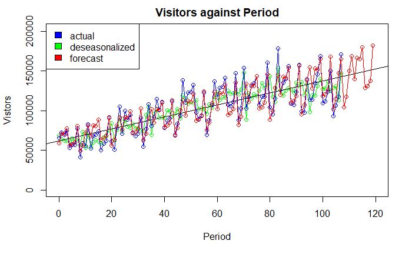

```r
lines(t2,Forecast_Visitors_CMV, type="o", col = "red")  #forecast
legend("topleft", c("actual", "deseasonalized", "forecast"), fill=c("blue","green", "red"))
```

*Residual analysis:*  
1.normality test  
H0: Errors are normally distributed.  
H1: Errors are not normally distributed.  
Since pvalue = 0.33 > 0.05, we do not reject H0.

2..Homoscedasticity & Heteroscedasticity  
H0: The variance of e is the same for all values of x.  
H1: The variance of e is not the same for all values of x.  
According to the plot, there is no sign of heteroscedasticity.

3.Dependence of the Error Variable  
H0 : Randomness exists.  
H1 : Randomness does not exist.  
Since pvalue = 0.12 > 0.05, we do not reject H0.

*Assessment*  
The standard error of estimate (11240) is samll compared to mean_y (102116.1). We can conclude that the model fit the data.

Testing the coefficients beta1.  
H0: beta1 = 0, H1: beta1 != 0  
Since p-value <2e-16 , we are 95% confident to reject H0. There is overwhelming evidence that t affects Des_x.

The # of visitors forecast for the next 12 months are 103985.464, 117180.3097, 150412.2532, 168658.8533, 139666.5789, 166648.7616, 164680.4456, 179521.0703, 128326.6933, 130843.7734, 137383.8476, 182221.0477 respectively.

## Smoothing by Linear Regression Model

```r
SLR_SI <- Linear_Regression_Seasonal_Index(Visitors, Quarter, Season)
cat("# # # # The Simple Linear_Regression seasonal index # # # ","\n")
```

```
# # # # The Simple Linear_Regression seasonal index # # #
```

```r
print(SLR_SI)
```

```
 [1] 0.7221720 0.8113474 1.0230255 1.1696572 0.9731046 1.1413538 1.1156423 1.2054987 0.8575849
[10] 0.8738024 0.9144179 1.1923934
```

### Forecast by seasonal index

```
### Linear Model ###
Call:
lm(formula = Des_x ~ t)

Residuals:
   Min     1Q Median     3Q    Max
-36203  -7171    175   7474  35953

Coefficients:
            Estimate Std. Error t value Pr(>|t|)
(Intercept) 61725.23    2144.43   28.78   <2e-16 ***
t             755.29      34.63   21.81   <2e-16 ***
---
Signif. codes:  0 ‘***’ 0.001 ‘**’ 0.01 ‘*’ 0.05 ‘.’ 0.1 ‘ ’ 1

Residual standard error: 11220 on 106 degrees of freedom
Multiple R-squared:  0.8178,    Adjusted R-squared:  0.816
F-statistic: 475.6 on 1 and 106 DF,  p-value: < 2.2e-16


    Shapiro-Wilk normality test

data:  Standard_E
W = 0.98513, p-value = 0.274

run test:[1] 0.02032634
The Outliers[1]  71  72  84  96 107
influential observations:[1] "no influential observations"
mean_y: 102133.1



deseasonalized data:
  [1]  67348.36  63629.70  61876.46  61873.15  61736.16  65146.31  61862.31  65290.53  57155.36
 [10]  72983.54  54162.88  70979.77  53769.14  59681.76  62514.66  61295.79  58286.94  66453.24
 [19]  67869.41  76249.17  84529.73  62281.58  76628.59  89448.43  72783.54  87249.90  79438.54
 [28]  78647.95  83954.37  77722.37  77306.01  75993.38  75054.15  94672.15 105553.58  68711.59
 [37]  94168.70 100599.83  90737.86  91877.33  91314.58 100091.28  98570.91  93514.44  96435.48
 [46] 102547.94  91381.89 118297.06 113138.91 107798.30 110570.38 109830.06 113342.72 101932.65
 [55] 102596.42 102622.18  96396.71 108181.78 104941.67 116837.65 120208.04 112441.03 116451.30
 [64] 117185.52 125306.55 120911.77 121424.79 123684.86 121263.36 126833.47 150548.55  87780.42
 [73] 119867.89 114415.88 120644.40 118682.83 125263.40 134443.43 128464.24 134252.68 144137.41
 [82] 117891.55 112949.29 152054.81 123359.81 118440.05 125117.16 129329.88 126934.37 122239.30
 [91] 135153.74 132209.73 136914.76 119842.63 136288.89  97274.66 116762.37 118100.10 130709.45
[100] 139908.90 127421.79 127327.41 135420.58 125759.67 129037.13 131190.42 114899.39 145755.53
```

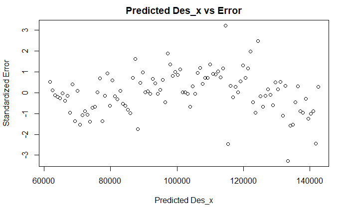

```r
Forecast_Visitors_SLR <- Forecast_by_SI(Visitors, Quarter, Season, SLR_SI, t)
```

```r
#cat("# # # # The Forecast_Visitors_y # # # ","\n")
#print(Forecast_Visitors_SLR)
lines(t, Visitors, type="o", col = "blue")    #actual
lines(t2,Forecast_Visitors_SLR, type="o", col = "red")  #forecast
```

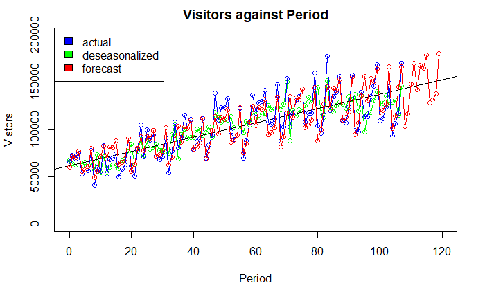

```r
legend("topleft", c("actual", "deseasonalized", "forecast"), fill=c("blue","green", "red"))
```

## Regression model by indicator variables

### The Regression Model

y = beta0 + beta1*t + beta2*Q1 + beta3*Q2 + beta4*Q3 + beta5*Q4 +beta6*Q5 +beta7*Q6 +beta8*Q7 +beta*9Q8 +beta10*Q9 +beta11*Q10 +vbeta12Q*11 +e where t = time in chronological order Qi = indicator variable (0, 1).

### Dummy as Quarter

```r
Dummy_I <- Season - 1    # n-1 indicator variables
Q <- matrix(nrow =n, ncol = Dummy_I)
Dummy_Name <- vector("character", length = Dummy_I)
for(i in 1:Dummy_I){
  Dummy_Name[i] <- paste0("Q", i)
}
colnames(Q) <- Dummy_Name
for(i in 1:n){
  for(j in 1:Dummy_I){
    if(Quarter[i] == j){
      Q[i,j] <- 1
    } else {
      Q[i,j] <- 0
    }
  }
}
```

### build the model

```r
Data.Visitors <- cbind(t, Q)  #t, Q1, Q2, Q3...
linearModelVar1 <- lm(Visitors ~ Data.Visitors)
cat("\n# # # # The regression model # # # ","\n")
```

```
# # # # The regression model # # #
```

```r
print(summary(linearModelVar1))
```

```
Call:
lm(formula = Visitors ~ Data.Visitors)

Residuals:
   Min     1Q Median     3Q    Max
-36431  -6467    204   7696  37291

Coefficients:
                  Estimate Std. Error t value Pr(>|t|)
(Intercept)       81728.93    4772.68  17.124  < 2e-16 ***
Data.Visitorst      753.25      39.57  19.034  < 2e-16 ***
Data.VisitorsQ1  -48410.14    6006.98  -8.059 2.26e-12 ***
Data.VisitorsQ2  -40245.95    6007.37  -6.699 1.47e-09 ***
Data.VisitorsQ3  -17732.32    6008.03  -2.951 0.003984 **
Data.VisitorsQ4   -3078.79    6008.94  -0.512 0.609582
Data.VisitorsQ5  -22585.00    6013.24  -3.756 0.000298 ***
Data.VisitorsQ6   -6740.48    6011.54  -1.121 0.265005
Data.VisitorsQ7   -8067.84    6010.11  -1.342 0.182673
Data.VisitorsQ8    1561.13    6008.94   0.260 0.795580
Data.VisitorsQ9  -33847.46    6008.03  -5.634 1.79e-07 ***
Data.VisitorsQ10 -32691.71    6007.37  -5.442 4.10e-07 ***
Data.VisitorsQ11 -28050.08    6006.98  -4.670 9.91e-06 ***
---
Signif. codes:  0 ‘***’ 0.001 ‘**’ 0.01 ‘*’ 0.05 ‘.’ 0.1 ‘ ’ 1

Residual standard error: 12740 on 95 degrees of freedom
Multiple R-squared:  0.8477,    Adjusted R-squared:  0.8285
F-statistic: 44.08 on 12 and 95 DF,  p-value: < 2.2e-16
```

```r
cat(" ","\n")
```

```r
ANOVA_T_lm <- anova(linearModelVar1)
cat("# # # # The ANOVA Table # # # ","\n")
```

```
# # # # The ANOVA Table # # #
```

```r
print(ANOVA_T_lm)
```

```
Analysis of Variance Table

Response: Visitors
              Df     Sum Sq    Mean Sq F value    Pr(>F)
Data.Visitors 12 8.5883e+10 7156948104  44.078 < 2.2e-16 ***
Residuals     95 1.5425e+10  162370303
---
Signif. codes:  0 ‘***’ 0.001 ‘**’ 0.01 ‘*’ 0.05 ‘.’ 0.1 ‘ ’ 1
```

```r
#residual analysis
SE_1 <- standarized_errors_MR(Visitors, Data.Visitors)[,1]
h_1 <- standarized_errors_MR(Visitors, Data.Visitors)[,2]
D_1 <- standarized_errors_MR(Visitors, Data.Visitors)[,3]
print(shapiro.test(SE_1) )          # normality
```

```
    Shapiro-Wilk normality test

data:  SE_1
W = 0.97765, p-value = 0.06569
```

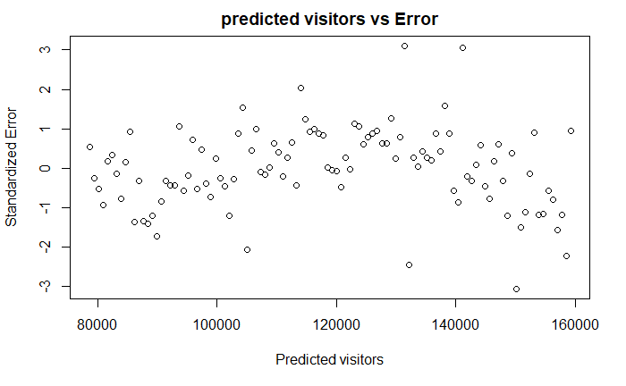

```r
b0<- coef(linearModelVar1)[1]             # Homoscedasticity & Heteroscedasticity
b1 <- coef(linearModelVar1)[2]
b2 <- coef(linearModelVar1)[3]
b3 <- coef(linearModelVar1)[4]
b4 <- coef(linearModelVar1)[5]
b5 <- coef(linearModelVar1)[6]
b6 <- coef(linearModelVar1)[7]
b7 <- coef(linearModelVar1)[8]
b8 <- coef(linearModelVar1)[9]
b9 <- coef(linearModelVar1)[10]
b10 <- coef(linearModelVar1)[11]
b11 <- coef(linearModelVar1)[12]
b12 <- coef(linearModelVar1)[13]
yhat <- vector("double", length = n)
for(i in 1:n) {
       yhat <- b0 + b1 *t + b2 *Q[i,1] + b3 *Q[i,2] + b4 *Q[i,3]+ b5 *Q[i,4]+ b6 *Q[i,5]+ b7 *Q[i,6]+ b8 *Q[i,7]+ b9 *Q[i,8]+ b10 *Q[i,9]+ b11 *Q[i,10]+ b12 *Q[i,11]
}
plot(x = yhat, y = SE_1, xlab = "Predicted visitors", ylab = "Standardized Error", main = "predicted visitors vs Error")
```

```r
cat("\nRun_Test:\n")
```

```
Run_Test:
```

```r
print(Run_Test(SE_1))              #errors are independent
```

```
[1] 0.006789827
```

```r
cat("\nThe Outliers\n")
```

```
The Outliers
```

```r
Outliers <- abs(SE_1) > 2
if(sum(Outliers)!=0){
    print(which(Outliers))
}else{
  print("no outliers")
}
```

```
[1]  36  48  71  72  84  96 107
```

```r
cat("\ninfluential observations:\n")
```

```
influential observations:
```

```r
k <- dim(Data.Visitors)[2]
Inf_Obs <- h_1 > 3*(k+1)/n
if(sum(Inf_Obs)!=0){
    print(which(Inf_Obs))
}else{
  print("no influential observations")
}
```

```
[1] "no influential observations"
```

```r
#assesment
cat("\nmean_y:",mean(Visitors),"\n")
```

```
mean_y: 102037.3
```

*Residual analysis:*  
Dependence of the Error Variable  
H0 : Randomness exists.  
H1 : Randomness does not exist.

Since the pvalue of run test = 0.006789827 < 0.05, we reject H0. Therefore, we do not use this method to forecast the number of visitors from Hong Kong.

## Error Metrics

```r
CMV_MAD <- Mean_Absolute_Deviation(Visitors, Forecast_Visitors_CMV, 1)  #actual y, predicted y
CMV_MSE <- Mean_Square_Error(Visitors, Forecast_Visitors_CMV, 1)
CMV_MAPE <- Mean_Absolute_Percentage_Error(Visitors, Forecast_Visitors_CMV, 1)
Error_M <- matrix(nrow = 3, ncol = 1)
colnames(Error_M) = c("CMV")
rownames(Error_M) = c("MAD", "MSE", "MAPE")
Error_M[1,1] <- CMV_MAD
Error_M[2,1] <- CMV_MSE
Error_M[3,1] <- CMV_MAPE
cat("\n# # # # Error Metrix # # # ","\n")
```

```
# # # # Error Metrix # # #
```

```r
print(Error_M)
```

```
              CMV
MAD  8.527714e+03
MSE  1.330884e+08
MAPE 8.778794e+00
```

## Conclusion:

By CMV, we forecast that the number of visitors from Hong Kong for the next 12 months will be 103985.464, 117180.3097, 150412.2532, 168658.8533, 139666.5789, 166648.7616, 164680.4456, 179521.0703, 128326.6933, 130843.7734, 137383.8476, 182221.0477 respectively.